# Extracting metadata from the netCDF files

Fadi Moubayed

9/14/2020

### Loading packages

```r
# JSON libraries
library(rjson)
library(RJSONIO)
library(jsonlite)

# To read the netCDF file (check for better options!)
library(ncdf4)

# To get the min bounding box
library(sp)
library(shotGroups)

# To plot the track of the glider
library(spacetime)
library(trajectories)
library(leaflet)

# To format dates
library(lubridate)

# ?? Not sure why I was using this
library(tidyverse)

# to format text in the console (does not format text in R markdown)
require(crayon)
```

## 1. Formatiing time and getting coordinates

### Writing a function to get the Time dimenson from the glider netCDF file

The following function gets the time dimension from the glider netCDF file and converts it from double to Unix time. The function also extracts the time stamp and the date as well. This function returns a dataframe that has the formatted time in addition the timestamp and the date. This function takes a ncdf4 object as an argument.

```r
formatTimeDim <- function(file){
    tryCatch(
        expr = {
            # Getting the time dimension
            time = file$dim$TIME
            # Formatting time
            time_formatted = as.POSIXct(time$vals, origin="1970-01-01")
            # Extracting the time stamp from the unix time object
            timeStamp = format(time_formatted,'%H:%M:%S')
            # Extracting the date from the unix time object
            date = as.Date(time_formatted)
            # Combining the formatted time, the time stamp and the date in one data frame
            all = cbind.data.frame(time_formatted, timeStamp, date)

            message('The time dimension has been successfully formatted!')
          # returning the dataframe
          return(all)

        },
        error = function(e){
            message('Caught an error!')
            print(e)
        },
        warning = function(w){
            message('Caught an warning!')
            print(w)
        }
    )
}
```

### Combining lat and long with time

This function should return a dataframe that has the lat, lon, the time formatted, time stamp and date with no NA data.

```r
combineLatLongWithTime <- function(filePath){
    tryCatch(
        expr = {
              # Reading the file
              file = nc_open(filePath)
              # Getting the latitude and longitude
              lon = ncvar_get(file,"LONGITUDE")
              lat = ncvar_get(file,"LATITUDE")
              # Calling the time function to get the dataframe that has the time formatted
              time = formatTimeDim(file)
              # Combining the time data frame with lat and long. This dataframe has NA values
              dataframe = cbind.data.frame(lat, lon, time)

              cat(bold("The number of NA this file has is: ", sum(is.na(dataframe))))
              cat("\n")

              # removing NA values
              dataframe_No_NA = dataframe %>% drop_na()

              return(dataframe_No_NA)

            message("dataframe successfully created!")
        },
        error = function(e){
            message('Caught an error!')
            print(e)
        },
        warning = function(w){
            message('Caught an warning!')
            print(w)
        }
    )
}
```

## 2. Getting the mission track

### A function to get the track of the netCDF file

This function takes the a datafram that has lat, lon, time_formatted, time stamp and date as an argument. This is the output of the function combineLatLongWithTime I am not sure how to select the first tow colomns of the dataframe that has lat, lon, time…… is it better if I put lat,lon in a seperate dataframe???? It looks to me that lat_lon_time_No_NA %>% select(1:2) makes things more complicated!!!

```r
getMissionTrack = function(lat_lon_time_No_NA){
  # Setting the reference system
  crs = CRS("+proj=longlat +datum=WGS84")
  # Creating a spatial points object
  sp = SpatialPoints(lat_lon_time_No_NA %>% select(1:2),crs)
  # Getting time
  time = lat_lon_time_No_NA$time_formatted
  # Providing the mission's coordinates
  data = data.frame(lat_lon_time_No_NA %>% select(1:2))
  # Creating an STIDF object
  stidf = STIDF(sp, time, data)
  # Creating a track object
  gliderTrack = Track(stidf)
  # Returning a track object
  return(gliderTrack)
}
```

### A function to get the first value of each day in the dataframe

This function also takes a dataframe that has lat, lon, time_fomratted, timestamp and date as an input. This is the output of the function combineLatLongWithTime.

```r
getMissionTrackLabels = function(lat_lon_time_No_NA){
  # Splitting the dataframe based on date
  # This results in a list of dataframes
  list = split(lat_lon_time_No_NA, lat_lon_time_No_NA$date)
  #This provides the first row of each day in the data frame
  first_days = do.call(rbind, (lapply(list, function(x) x[1,])))
  return(first_days)
}
```

### Generalizing the mission track

This function should generalize the mission track. I still need to decide what method I should use for generalization. (distance or time) I also need to think what kind of structure I need to put the generalized track in. This function is not complete yet.

```r
generalizeMissionTrack = function(missionTrack){
  generalize(missionTrack)
}
```

## 3. Plotting Tracks

### A function to plot the track of the netCDF file

This function takes the output of the function getMissionTrack and plots it on a leaflet map in R. This function is only meant to explore how the tracks are plotted and therefore it is not part of the metadata that needs to be transported.

```r
plotMissionTrack = function(gliderTrack){
  # plotting the map
   return(leaflet() %>%addTiles() %>% addPolylines(lat = gliderTrack@data[,1], lng = gliderTrack@data[,2]))
}
```

### A function to plot the mission track with labels

I’m still thinking of plotting the first value of the mission in green and the last value in red. I think this requiers extracting the first value in a separate list or a dataframe and the same for the last value and then add them to the plotting function.

```r
plotMissionTrackWithLabels = function(lat_lon_time_No_NA, gliderTrack){
  track = plotMissionTrack(gliderTrack)
  first_days = getMissionTrackLabels(lat_lon_time_No_NA)
  return (track %>% addAwesomeMarkers(data = first_days, lat = ~first_days$lat, lng = ~first_days$lon, label = first_days$time_formatted))
}
```

## 4. Getting the minimum bounding box

### Getting the minimum bounding box

There are many ways for getting the minimum bounding box Creating a Track object includes having the time span and the minumum bounding box The only problem is that I don’t know how to get that information saved in a variable When I create a Track object and type the object name in the console, I get the information but I don’t know how to save it in a new variable.

The sp library has a function for getting the bbox but this includes creating a SpatialPoints object

### Getting the min bounding box using the library sp

I am not sure about whether I should provide the file path to this function and call the combineLatLongWithTime function inside this function or I should simply supply the lat_lon_time_No_NA directly.

```r
getminBBoxUsingSp = function(lat_lon_time_No_NA){
  # Creating a spatial points object out of the lat_lon_time_No_NA
  spatialPoints = SpatialPoints(lat_lon_time_No_NA %>% select(1:2))
  # Creating the bounding box
  bb_sp = bbox(spatialPoints)
  return(bb_sp)
}
```

This is the old version of getting the bbox using the library sp where the path to the file was provided instead of lat_lon_time_No_NA

```r
# lat_lon_time_No_NA_File1 = combineLatLongWithTime(file_Path_File1)
# Converting the dataframe to a SpatialPoints object
# lat_lon_spatial_file1 = SpatialPoints(lat_lon_time_No_NA_File1 %>% select(1:2))
# Applying the bbox function
# bb_sp = bbox(lat_lon_spatial_file1)

# head(lat_lon_spatial_file1)
# bb_sp
```

## 5. Testing the functions

## Testing the functions

This part is for testing the functions

### Providing the path to the netCDF test file

```r
# This is where the netCDF data files reside
netCDF_Data_Files_Path = "/home/fadi/DataX1/University/WWU/WWU 5/netCDF sample files/"

#File1
# This is the files that needs to be read
netCDF_File1_Name = "wallis_mooset01_R.nc"
# This is the complete path to the netCDF file that is being read
file_Path_File1 = paste0(netCDF_Data_Files_Path,netCDF_File1_Name)

#File2
# This is the files that needs to be read
netCDF_File2_Name = "sg558_fram_jun2013_R.nc"
# This is the complete path to the netCDF file that is being read
file_Path_File2 = paste0(netCDF_Data_Files_Path,netCDF_File2_Name)

#File3
# This is the files that needs to be read
netCDF_File3_Name = "ideep02_0012_R.nc"
# This is the complete path to the netCDF file that is being read
file_Path_File3 = paste0(netCDF_Data_Files_Path,netCDF_File3_Name)
```

### Testing plotting the mission track for multiple files

```r
#plotMissionTracks(file_Path_File1)
#plotMissionTracks(file_Path_File2)
#plotMissionTracks(file_Path_File3)
```

```r
lat_lon_time_No_NA_File1= combineLatLongWithTime(file_Path_File3)
```

```
## The time dimension has been successfully formatted!
```

```
## The number of NA this file has is:  64
```

```r
mission_Track_File3 = getMissionTrack(lat_lon_time_No_NA_File1)
mission_Track_File3_generalized = generalize(mission_Track_File3, distance = 100)
```

### Getting the bbox using the library shotGroups

This function also returns the width and height of the bounding box. Since the projection is WGS84. This information is not useful.

```r
lat_lon = lat_lon_time_No_NA_File1 %>% select(1:2)
names(lat_lon)[1] = "point.x"
names(lat_lon)[2] = "point.y"
bb = getBoundingBox(lat_lon)
bb
```

```
## $pts
##    xleft  ybottom   xright     ytop
## 38.94962  0.13503 39.49425  2.53725
##
## $width
## [1] 0.54463
##
## $height
## [1] 2.40222
##
## $FoM
## [1] 1.473425
##
## $diag
## [1] 2.463185
```

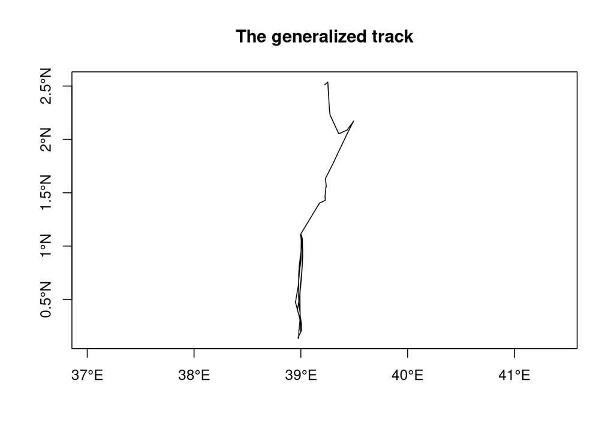

```r
# plot(mission_Track_File3)
plot(mission_Track_File3_generalized, main = "The generalized track")
```

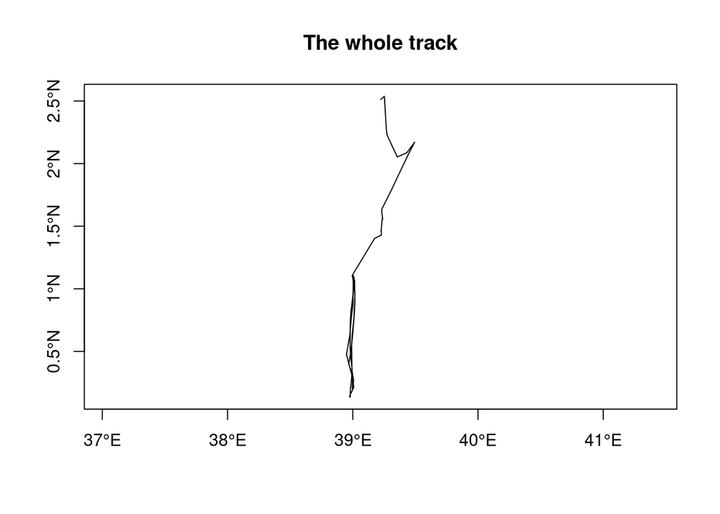

```r
plot(mission_Track_File3, main = "The whole track")
```

This function plots the generalized mission track The generalize function in trajectories is throwing me the following error: “CRS object has comment, which is lost in output” I don’t think this function is necessary because there is already a function that plots Tracks which is called plotMissionTrack

```r
plotMissionTrackGeneralized = function(lat_lon_time_No_NA){
  # Setting the reference system
  crs = CRS("+proj=longlat +datum=WGS84")
  # Creating a spatial points object
  sp = SpatialPoints(lat_lon_time_No_NA %>% select(1:2),crs)
  # Getting time
  time = lat_lon_time_No_NA$time_formatted
  # Getting data
  data = data.frame(lat_lon_time_No_NA %>% select(1:2))
  # Creating an STIDF object
  stidf = STIDF(sp, time, data)
  # Creating a track object
  glider_track = Track(stidf)
  # Generalizing the track
  glider_track_generalized = generalize(glider_track, distance = 100)
  # plotting the map
   return(leaflet() %>%addTiles() %>% addPolylines(lat = glider_track_generalized@data[,1], lng = glider_track_generalized@data[,2]))
}

plotMissionTrackGeneralized(lat_lon_time_No_NA_File1)
```

[interactive chart not shown]